# Week 7: Life Tables and Matrix Modeling

EFB 370 - Spring 2023

E. Gurarie, E. Khadonova

2023-03-20

# Life History Tables

> This portion of the lab was originally developed by [Prof. Owen Jones](https://www.transmittingscience.com/instructors/owen-r-jones/) as part of a [course similar to ours](https://jonesor.github.io/BB512_Book/) taught at Odense University in Denmark.

Life tables are tables that show the probability that an individual of a given age class will die before their next birthday (*probability of death*). This exercise deals with **cohort life tables**, which follow a “*cohort*” from when they’re all born until they all die. A cohort is the group of individuals born within a particular time interval (e.g., “*all individuals born in 1998*”).

Life tables are used extensively in population biology, human demography, and epidemiology.

### Learning Objectives:

1. Increased competence in using Excel formulae for biological modeling
2. Understanding how life tables are calculated
3. Understanding the three types of survivorship curves

Download and open the “Life Tables” Excel file from the Recitations folder on Blackboard.

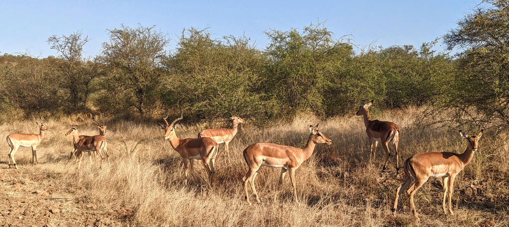

Impala (*Aepyceros melampus*). Photo by [Nate Wehr](https://nathanielwehr.weebly.com/).

The aim is to use Excel as a modeling tool to produce a life table. We have provided some initial data collected from a cohort of impala ewes. We know how many individuals survived each year ($S_x$). We also know how many babies were produced by the cohort each year ($B_x$). We can therefore use this information to calculate the growth rate of the impala population we’re studying.

#### 1. Survivorship ($l_x$)

Survivorship is the **probability of survival to a particular age**. Therefore, at time 1, $l_1 = 1$, since everyone is alive at this point. The next value ($l_2$) must be calculated based on the number alive at that point. In algebraic form, the equation is $l_x = S_x/S_0$. So, for $l_2$, you would do $352/500 = 0.704$. Generalize this calculation into a formula that can be dragged to fill column “D” in the worksheet.

#### 2. Survival probability ($g_x$)

**Survival probability** is different from $l_x$; it is the probability that an individual will survive its current age class. The calculation is $g_x = l_{x+1}/l_x$, or $S_{x+1}/S_x$. For example, $g_2 = 298/352 = 0.85$. This is the probability that an individual currently age 2 will survive to become age 3. Generalize this calculation into a formula that can be dragged to fill column “E” in the worksheet.

#### 3. Birth rate ($b_x$)

We will next calculate the mean number of offspring produced by each female ($b_x$). We can calculate this for each age class by dividing the number of offspring produced ($B_x$) by the number of females alive ($S_x$). So, $b_6 = 189/172 = 1.10$. Generalize this calculation into a formula that can be dragged to fill column “F” in the worksheet.

#### 4. Reproductive rate ($R_x$)

The reproductive rate combines female survival and birth rates. We calculate **reproductive rate** ($R_x$) using $R_x = l_x * b_x$. Generalize this calculation into a formula that can be dragged to fill column “G” in the worksheet.

#### 5. Generation time ($G_x$)

The last column is our **generation time** ($G_x$). Generation time can be calculated as $G_x = x * R_x$. Generalize this calculation into a formula that can be dragged to fill column “H” in the worksheet.

#### 6. The important bits!

Below our life tables, we have spots for $R_0$, $G$, and $r$. The important one we want to get to is $r$, but first we have to calculate $R_0$ and $G$.

- The **net reproductive rate** ($R_0$) is the sum of the age-specific reproduction rates. We use the equation $R_0 = \sum R_x$. This can be done in excel using the sum function `=sum()`.
- The **generation time** ($G$) is a trickier concept, but basically is the average age of a female giving birth. We use the equation $G = \sum G_x /R_0$
- The overal population growth rate is then $r = log(R_0) / G$. In Excel, the log function is `=log()`.

> Exercise 1:

> Once you calculate $r$, your table is complete. Take a screenshot of the table and save it to a word document. On the lab computers, this can be done using the `Snipping Tool`, which is accessed by using the search bar in the bottom left corner of your screen.

> On the same word document: in a few sentences explain what the $r$-value you received means about this population of impala, and how we might use this information to manage them.

# Matrix Models

In the window of Matrix Modeller, you will see the Leslie matrix on the top left, with 3 rows (age classes) and 3 columns and some numbers already entered. Please note that the number of rows and columns should always be **equal**! **If you click on the empty cell, it will automatically create a new row**, which may produce an error saying “Non-square matrix.” If that happens, try pressing a little [x] button to remove any accidentally created rows or columns.

You can add new rows or columns by clicking on the empty ones and typing in a name. Once you type a name in, you can click on some other part of the screen and it will be entered. You can also change the existent names - try changing the row names from I, II, and III to “larva,” “juvenile,” and “adult.”

Under the Leslie Matrix, you have your population vector (bottom left), where you can enter how many individuals you have for each of the age classes. You can see that there are 20 individuals in class I, 0 in class II, and 0 in class III in by default.

There are three buttons on the bottom: `Draw diagram`, `Compute eigenvalues` and `Run simulation`. Try clicking each one and see what it gives you. Note: if you change any of the parameters, you have to click **each button again** to get a new value or graph! If you want to start over, press the `Clear everything button`.

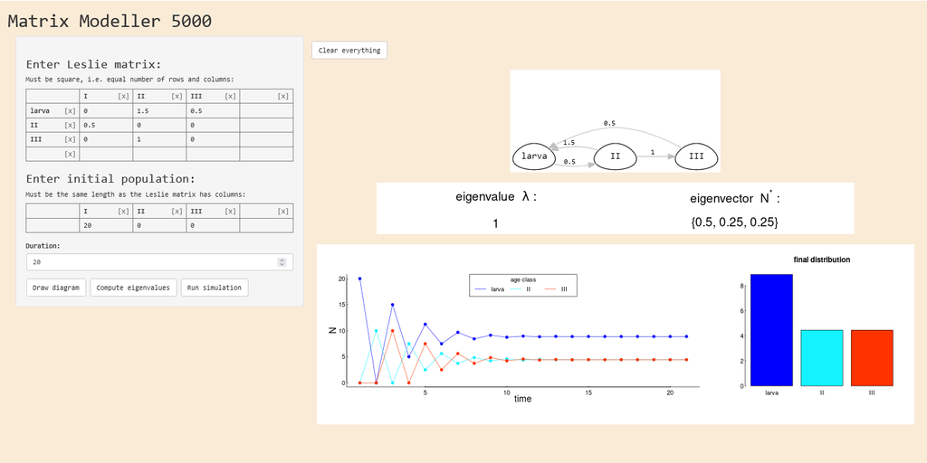

For all the following processes, obtain (a) population growth $\lambda$ and (b) the stationary distribution $N^*$. Then, answer remaining questions as they come up.

## 1. *Monocerus academicus*

[interactive chart not shown]

> **Exercise 2:**

> Change the fecundity of emeritus Monocerus to 0.7. Report the resulting growth rate ($\lambda$) and stable population distribution ($N^{*}$).

## 2. A butterfly

Butterflies lay eggs that hatch into caterpillars and become adults. Not all caterpillars become adults right away, leading to the following diagram:

[interactive chart not shown]

> **Exercise 3:**

> Report $\lambda$ and $N^{*}$. How many **eggs** must adults lay to make the growth rate $\lambda = 1$?

## 3. Tasmanian Devil

Pre infectious facial tumor disease, the life history populaiton matrix for Tasmanian devils looked something like this:

[interactive chart not shown]

> **Exercise 4:**

> Report $\lambda$ and $N^{*}$.

# **Homework Assignment**

## (Due: Thursday, March 23)

> After facial tumor disease emerged and established itself in the Tasmanian devil population, annual mortality of 2 year olds and 3-plus year olds skyrocketed to 90%. This had an immediate impact on the population growth factor $\lambda$.
> 1. (**3 pts.**) Changing only those survival probabilities, what is the new population growth factor? What is the new stable age distribution?
> 2. (**2 pts.**) As a population-level response, Tasmanian devils radically increased the number of “precocial” births, i.e. 1 yr olds that reproduce. How high must 1 year old birth rates become to rescue the Tasmanian devil population?

> **Extra credit:** Can a **stable age distribution** have higher proportions of older animals? Explain why or why not?

[figure not shown]

**Is this Gen Z humor? If so, I don’t get it.**